# amazon_bestsellers

Jun

2022-09-25

## Dataset Description

The dataset used for this project is the Amazon Top 50 Bestselling Books from 2009-2019 extracted from [kaggle](https://www.kaggle.com/datasets/sootersaalu/amazon-top-50-bestselling-books-2009-2019).  
The columns in this dataset consist of:

1. **Name** - The name of the book
2. **Author** - The writer of the book
3. **User Rating** - The rating of the book from a scale of 1-5
4. **Reviews** - The total count of reviews for the book
5. **Price** - The cost of the book in USD (As of 13/10/2020)
6. **Year** - The year(s) it was ranked on bestseller
7. **Genre** - Fiction or Non-fiction

## Project Description

For this project, I will be performing Exploratory Data Analysis (EDA) and will visualize the data using the ggplot2 library in R. Here are some of the questions I’ll be answering throughout the project:

1. What is the relationship between user rating and other variables?
2. Which genres become bestsellers more often?
3. Which authors have the most best sellers?
4. What is the trend of the genres over the years?
5. Distribution of the ratings
6. What are the top 5 multiple bestseller books?
7. What are the top 10 most expensive bestseller books?
8. Who are the authors with the highest prices on average?

## Exploratory Data Analysis (EDA)

### Importing libraries

```r
library(ggplot2)
library(dplyr)
library(janitor)
library(tidyverse)
library(stringr)
library(gt)
library(ggcorrplot)
```

### Loading in dataset

```r
bestsellers = read_csv("bestsellers.csv") # Importing datasaet
```

```r
# Previewing data
head(bestsellers)
```

```
## # A tibble: 6 × 7
##   Name                                  Author User …¹ Reviews Price  Year Genre
##   <chr>                                 <chr>    <dbl>   <dbl> <dbl> <dbl> <chr>
## 1 10-Day Green Smoothie Cleanse         JJ Sm…     4.7   17350     8  2016 Non …
## 2 11/22/63: A Novel                     Steph…     4.6    2052    22  2011 Fict…
## 3 12 Rules for Life: An Antidote to Ch… Jorda…     4.7   18979    15  2018 Non …
## 4 1984 (Signet Classics)                Georg…     4.7   21424     6  2017 Fict…
## 5 5,000 Awesome Facts (About Everythin… Natio…     4.8    7665    12  2019 Non …
## 6 A Dance with Dragons (A Song of Ice … Georg…     4.4   12643    11  2011 Fict…
## # … with abbreviated variable name ¹`User Rating`
```

```r
# Viewing data types for each column
str(bestsellers)
```

```
## spec_tbl_df [550 × 7] (S3: spec_tbl_df/tbl_df/tbl/data.frame)
##  $ Name       : chr [1:550] "10-Day Green Smoothie Cleanse" "11/22/63: A Novel" "12 Rules for Life: An Antidote to Chaos" "1984 (Signet Classics)" ...
##  $ Author     : chr [1:550] "JJ Smith" "Stephen King" "Jordan B. Peterson" "George Orwell" ...
##  $ User Rating: num [1:550] 4.7 4.6 4.7 4.7 4.8 4.4 4.7 4.7 4.7 4.6 ...
##  $ Reviews    : num [1:550] 17350 2052 18979 21424 7665 ...
##  $ Price      : num [1:550] 8 22 15 6 12 11 30 15 3 8 ...
##  $ Year       : num [1:550] 2016 2011 2018 2017 2019 ...
##  $ Genre      : chr [1:550] "Non Fiction" "Fiction" "Non Fiction" "Fiction" ...
##  - attr(*, "spec")=
##   .. cols(
##   ..   Name = col_character(),
##   ..   Author = col_character(),
##   ..   `User Rating` = col_double(),
##   ..   Reviews = col_double(),
##   ..   Price = col_double(),
##   ..   Year = col_double(),
##   ..   Genre = col_character()
##   .. )
##  - attr(*, "problems")=<externalptr>
```

From the results above, we can see that we have 3 character variables (Name, Author, Genre) and 4 numerical or double variables (User Rating, Reviews, Price, and Year).

```r
# Looking at the dimensions of the dataset
dim(bestsellers)
```

```
## [1] 550   7
```

We can see here that there are 550 total records of books each containing seven attributes.

### Checking for missing values

```r
sum(is.na(bestsellers))
```

```
## [1] 0
```

The dataset has no missing values, meaning we can proceed onto the next steps.

### Checking for duplicates

```r
# Checking for duplicate rows
get_dupes(bestsellers, Name, Author, 'User Rating', Reviews, Price, Year, Genre)
```

```
## No duplicate combinations found of: Name, Author, User Rating, Reviews, Price, Year, Genre
```

```
## # A tibble: 0 × 8
## # … with 8 variables: Name <chr>, Author <chr>, User Rating <dbl>,
## #   Reviews <dbl>, Price <dbl>, Year <dbl>, Genre <chr>, dupe_count <int>
```

The results show that there are no duplicate rows in the data.

Now, let’s check if the categorical columns contain words in different cases and extra spaces

```r
bestsellers %>%
  mutate_if(is.character, str_trim)
```

```
## # A tibble: 550 × 7
##    Name                                 Author User …¹ Reviews Price  Year Genre
##    <chr>                                <chr>    <dbl>   <dbl> <dbl> <dbl> <chr>
##  1 10-Day Green Smoothie Cleanse        JJ Sm…     4.7   17350     8  2016 Non …
##  2 11/22/63: A Novel                    Steph…     4.6    2052    22  2011 Fict…
##  3 12 Rules for Life: An Antidote to C… Jorda…     4.7   18979    15  2018 Non …
##  4 1984 (Signet Classics)               Georg…     4.7   21424     6  2017 Fict…
##  5 5,000 Awesome Facts (About Everythi… Natio…     4.8    7665    12  2019 Non …
##  6 A Dance with Dragons (A Song of Ice… Georg…     4.4   12643    11  2011 Fict…
##  7 A Game of Thrones / A Clash of King… Georg…     4.7   19735    30  2014 Fict…
##  8 A Gentleman in Moscow: A Novel       Amor …     4.7   19699    15  2017 Fict…
##  9 A Higher Loyalty: Truth, Lies, and … James…     4.7    5983     3  2018 Non …
## 10 A Man Called Ove: A Novel            Fredr…     4.6   23848     8  2016 Fict…
## # … with 540 more rows, and abbreviated variable name ¹`User Rating`
```

```r
# Checking unique values in Name column
unique(bestsellers$Name)
```

```
##   [1] "10-Day Green Smoothie Cleanse"
##   [2] "11/22/63: A Novel"
##   [3] "12 Rules for Life: An Antidote to Chaos"
##   [4] "1984 (Signet Classics)"
##   [5] "5,000 Awesome Facts (About Everything!) (National Geographic Kids)"
##   [6] "A Dance with Dragons (A Song of Ice and Fire)"
##   [7] "A Game of Thrones / A Clash of Kings / A Storm of Swords / A Feast of Crows / A Dance with Dragons"
##   [8] "A Gentleman in Moscow: A Novel"
##   [9] "A Higher Loyalty: Truth, Lies, and Leadership"
##  [10] "A Man Called Ove: A Novel"
##  [11] "A Patriot's History of the United States: From Columbus's Great Discovery to the War on Terror"
##  [12] "A Stolen Life: A Memoir"
##  [13] "A Wrinkle in Time (Time Quintet)"
##  [14] "Act Like a Lady, Think Like a Man: What Men Really Think About Love, Relationships, Intimacy, and Commitment"
##  [15] "Adult Coloring Book Designs: Stress Relief Coloring Book: Garden Designs, Mandalas, Animals, and Paisley Patterns"
```

[output cut: 336 more lines]

```r
# Checking unique values in Author column
sort(unique(bestsellers$Author))
```

```
##   [1] "Abraham Verghese"
##   [2] "Adam Gasiewski"
##   [3] "Adam Mansbach"
##   [4] "Adir Levy"
##   [5] "Admiral William H. McRaven"
##   [6] "Adult Coloring Book Designs"
##   [7] "Alan Moore"
##   [8] "Alex Michaelides"
##   [9] "Alice Schertle"
##  [10] "Allie Brosh"
##  [11] "American Psychiatric Association"
##  [12] "American Psychological Association"
##  [13] "Amor Towles"
##  [14] "Amy Ramos"
##  [15] "Amy Shields"
```

[output cut: 233 more lines]

From the results, we can see that the authors J.K Rowling and George R.R. Martin have multiple entries due to different spellings.

```r
# Fixing J.K. Rowling and George R.R Martin Entries
bestsellers$Author <- str_replace(bestsellers$Author, "J. K. Rowling", "J.K. Rowling")
bestsellers$Author <- str_replace(bestsellers$Author, "George R. R. Martin", "George R.R. Martin")
sort(unique(bestsellers$Author)) # Checking if changes worked correctly
```

```
##   [1] "Abraham Verghese"
##   [2] "Adam Gasiewski"
##   [3] "Adam Mansbach"
##   [4] "Adir Levy"
##   [5] "Admiral William H. McRaven"
##   [6] "Adult Coloring Book Designs"
##   [7] "Alan Moore"
##   [8] "Alex Michaelides"
##   [9] "Alice Schertle"
##  [10] "Allie Brosh"
##  [11] "American Psychiatric Association"
##  [12] "American Psychological Association"
##  [13] "Amor Towles"
##  [14] "Amy Ramos"
##  [15] "Amy Shields"
```

[output cut: 231 more lines]

```r
# Checking Genre Column
unique(bestsellers$Genre)
```

```
## [1] "Non Fiction" "Fiction"
```

Everything is fine with the Genre Column.

Now that the data is cleaned up, we can look into the questions from above!

### Distribution of ratings

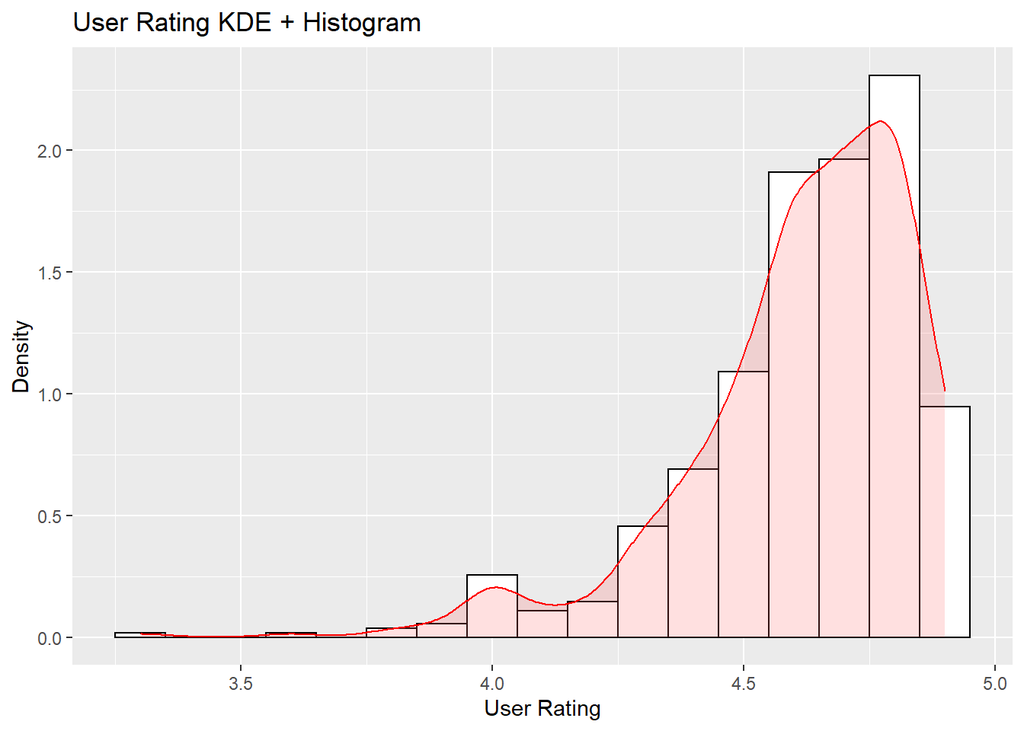

```r
# Kernel Density Plot + Histogram
bestsellers %>%
  ggplot(aes(x=`User Rating`)) +
  geom_histogram(aes(y=..density..), binwidth=0.1, colour="black", fill="white") +
  geom_density(alpha=0.2, fill="#FF6666", colour="red") +
  labs(title = "User Rating KDE + Histogram") +
  xlab("User Rating") +
  ylab("Density")
```

### Highest rated books

```r
max_rating <- max(bestsellers$`User Rating`) # To get the highest user rating

best_rated_books <- bestsellers %>%
  filter(bestsellers$`User Rating` == max_rating)

best_rated_books <- best_rated_books %>% # Getting rid of duplicate rows for variables Name and Author
  distinct(Name, Author)


best_rated_books_title_author <- best_rated_books %>%
  select(Name, Author) %>%
  gt() %>%
  tab_header(
    title = "Highest rated books and authors"
  )

best_rated_books_title_author
```

Highest rated books and authors

| Name | Author |
| --- | --- |
| Brown Bear, Brown Bear, What Do You See? | Bill Martin Jr. |
| Dog Man and Cat Kid: From the Creator of Captain Underpants (Dog Man #4) | Dav Pilkey |
| Dog Man: A Tale of Two Kitties: From the Creator of Captain Underpants (Dog Man #3) | Dav Pilkey |
| Dog Man: Brawl of the Wild: From the Creator of Captain Underpants (Dog Man #6) | Dav Pilkey |
| Dog Man: Fetch-22: From the Creator of Captain Underpants (Dog Man #8) | Dav Pilkey |
| Dog Man: For Whom the Ball Rolls: From the Creator of Captain Underpants (Dog Man #7) | Dav Pilkey |
| Dog Man: Lord of the Fleas: From the Creator of Captain Underpants (Dog Man #5) | Dav Pilkey |
| Goodnight, Goodnight Construction Site (Hardcover Books for Toddlers, Preschool Books for Kids) | Sherri Duskey Rinker |
| Hamilton: The Revolution | Lin-Manuel Miranda |
| Harry Potter and the Chamber of Secrets: The Illustrated Edition (Harry Potter, Book 2) | J.K. Rowling |
| Harry Potter and the Goblet of Fire: The Illustrated Edition (Harry Potter, Book 4) (4) | J.K. Rowling |
| Harry Potter and the Prisoner of Azkaban: The Illustrated Edition (Harry Potter, Book 3) | J.K. Rowling |
| Harry Potter and the Sorcerer's Stone: The Illustrated Edition (Harry Potter, Book 1) | J.K. Rowling |
| Humans of New York : Stories | Brandon Stanton |
| Jesus Calling: Enjoying Peace in His Presence (with Scripture References) | Sarah Young |
| Last Week Tonight with John Oliver Presents A Day in the Life of Marlon Bundo (Better Bundo Book, LGBT Childrens Book) | Jill Twiss |
| Little Blue Truck | Alice Schertle |
| Obama: An Intimate Portrait | Pete Souza |
| Oh, the Places You'll Go! | Dr. Seuss |
| Rush Revere and the Brave Pilgrims: Time-Travel Adventures with Exceptional Americans (1) | Rush Limbaugh |
| Rush Revere and the First Patriots: Time-Travel Adventures With Exceptional Americans (2) | Rush Limbaugh |
| Strange Planet (Strange Planet Series) | Nathan W. Pyle |
| The Legend of Zelda: Hyrule Historia | Patrick Thorpe |
| The Magnolia Story | Chip Gaines |
| The Very Hungry Caterpillar | Eric Carle |
| The Wonderful Things You Will Be | Emily Winfield Martin |
| Unfreedom of the Press | Mark R. Levin |
| Wrecking Ball (Diary of a Wimpy Kid Book 14) | Jeff Kinney |

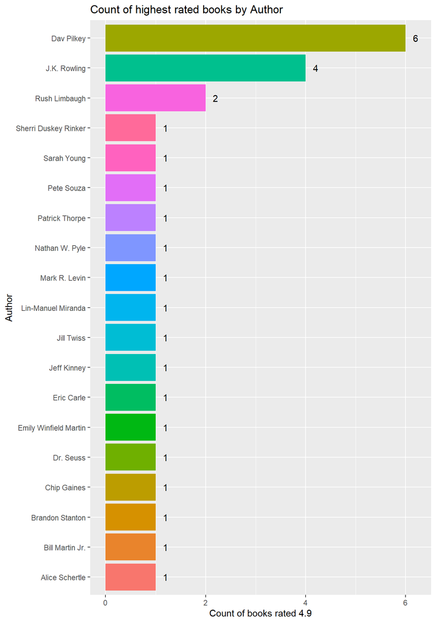

```r
# Distribution of authors with highest rated bestsellers

authors_count <- best_rated_books %>%
  group_by(Author) %>%
  summarize(count=n())

authors_count <- authors_count[order(authors_count$count),]

authors_count %>%
  ggplot(aes(x=reorder(Author, count), y=count, fill=Author)) +
  geom_col() +
  geom_text(aes(label=count), nudge_y = 0.2) +
  coord_flip() +
  labs(title="Count of highest rated books by Author") +
  ylab("Count of books rated 4.9") +
  xlab("Author") +
  theme(legend.position = "none")
```

From this graph, we can see that Dav Pilkey wrote the highest number of bestsellers rated 4.9.

### Author with the most number of bestsellers

```r
author_ct <- bestsellers %>%
  count(Author)

max_count <- max(author_ct$n) # Getting the max number of books
author_ct[author_ct$n == max_count,] # Finding the author based on the max number of books
```

```
## # A tibble: 1 × 2
##   Author          n
##   <chr>       <int>
## 1 Jeff Kinney    12
```

The author who wrote the most bestsellers is Jeff Kinney (Author of Diary of a Wimpy Kid) with 12 books.

### Count of books by genre

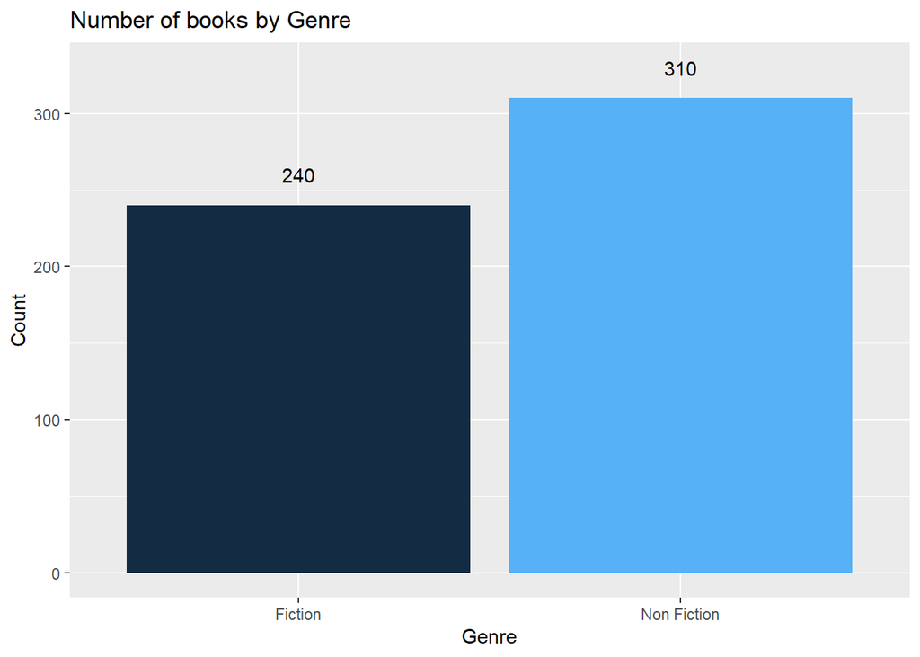

```r
frequency_genre <- bestsellers %>% count(bestsellers$Genre)
names(frequency_genre) <- c("Genre", "Count")


frequency_genre %>%
  ggplot(aes(x=Genre, y=Count, fill=Count)) +
  geom_bar(stat='identity') +
  geom_text(aes(label=Count), nudge_y = 20) +
  theme(legend.position="none") +
  labs(title="Number of books by Genre")
```

From the bar chart above, we can see that there are 70 more Non Fiction bestsellers than Fiction bestsellers.

### Top 10 Most Expensive Bestsellers

```r
highest_price_books <- bestsellers[order(-bestsellers$Price),]
highest_price_books <- highest_price_books %>% # removes duplicate entries over multiple years
  distinct(Name, Author, Price)

highest_price_books <- highest_price_books %>% # Select top 10 highest priced books
  top_n(10)
```

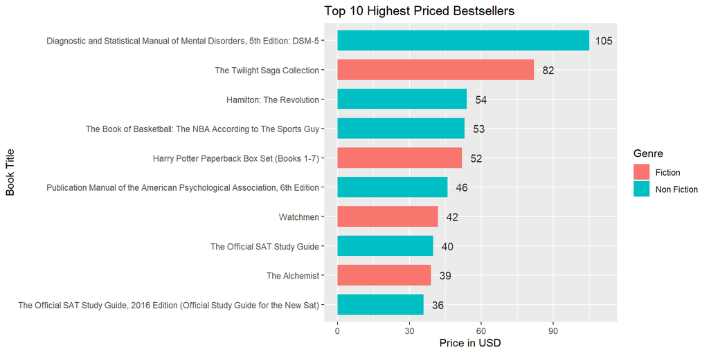

```r
name_genre_df <- select(bestsellers, Name, Genre)

# Inner join top 10 books and bestsellers to add Genre to highest_price_books
highest_price_books <- inner_join(x=highest_price_books, y=name_genre_df, by="Name")
highest_price_books <- unique(highest_price_books) # remove duplicate entries over multiple years from the inner join

highest_price_books %>%
  ggplot(aes(x=reorder(Name, Price), y = Price, fill=Genre)) +
  geom_bar(stat='identity', width=0.7) +
  geom_text(aes(label=Price), nudge_y=6, alpha=0.8) +
  coord_flip() +
  labs(title="Top 10 Highest Priced Bestsellers") +
  xlab("Book Title") +
  ylab("Price in USD")
```

From this bar graph, we can see the top 10 highest priced books with the the highest price being $105 and the lowest being $36. Additionally, we can see that out of the 10 books, six are Non-Fiction and four are Fiction.

### Relationship between User Rating and Other Independent Variables

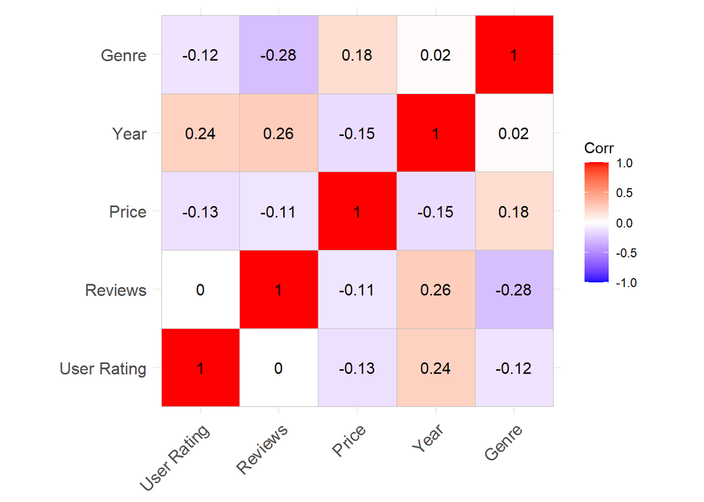

```r
# prepare data frame for correlation matrix as attributes should be numerical
corr_df <- bestsellers %>%
  select(`User Rating`, Reviews, Price, Year, Genre)

corr_df$Genre <- as.numeric(factor(corr_df$Genre)) # 2 = Nonfiction, 1 = Fiction

corr <- corr_df %>% # Correlation Matrix
  cor()

ggcorrplot(corr, lab=TRUE)
```

From the correlation matrix, we can see that there is no linear correlation between User Rating and Reviews. We can also see that there are very weak negative correlations between (User Rating, Price) and (User Rating, Genre) and very weak positive correlations between User Rating and Year.

### Top 5 Highest Occurences of Bestsellers

```r
highest_freq <- bestsellers %>%
  count(Name, name="Count")

highest_freq <- highest_freq[order(-highest_freq$Count),] %>%
  top_n(5)
```

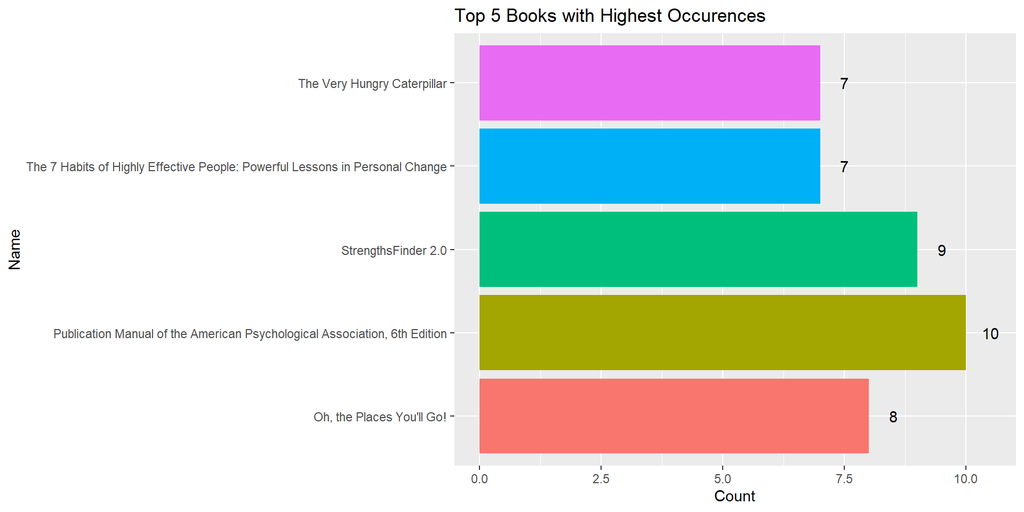

```r
highest_freq %>%
  ggplot(aes(x=Name, y=Count, fill=Name)) +
  geom_bar(stat='identity') +
  coord_flip() +
  theme(legend.position="none") +
  geom_text(aes(label=Count), nudge_y=0.5) +
  labs(title="Top 5 Books with Highest Occurences")
```

From this graph, we can see that the Publication Manual of the American Psychological Association had the highest occurrences as a bestsellers over the years (10 years).

### Trends over the years

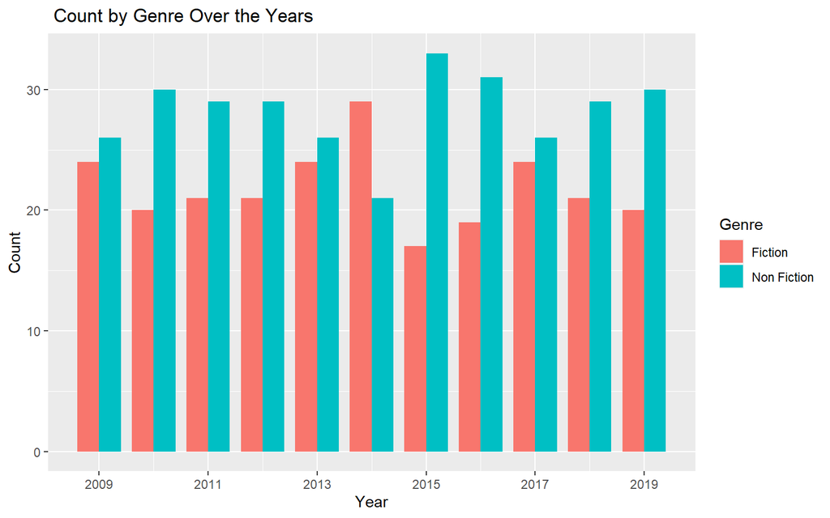

```r
# Viewing trend of Genre over the years
genre_years <- bestsellers %>%
  count(Year, Genre, name="Count")

genre_years %>%
  ggplot(aes(x=Year, y=Count, fill=Genre)) +
  geom_bar(stat='identity', show.legend = TRUE, position="dodge", width=0.8) +
  xlim(2009, 2019) +
  scale_x_continuous(breaks=c(2009, 2011, 2013, 2015, 2017, 2019)) +
  labs(title=" Count by Genre Over the Years")
```

From this graph, we can see that there were more Nonfiction books than Fiction books in the majority of the years with the exception of 2014.

```r
# Average price by genre over the years
avg_price_by_genre <- bestsellers %>%
  group_by(Genre, Year) %>%
  summarize(mean = mean(Price))
```

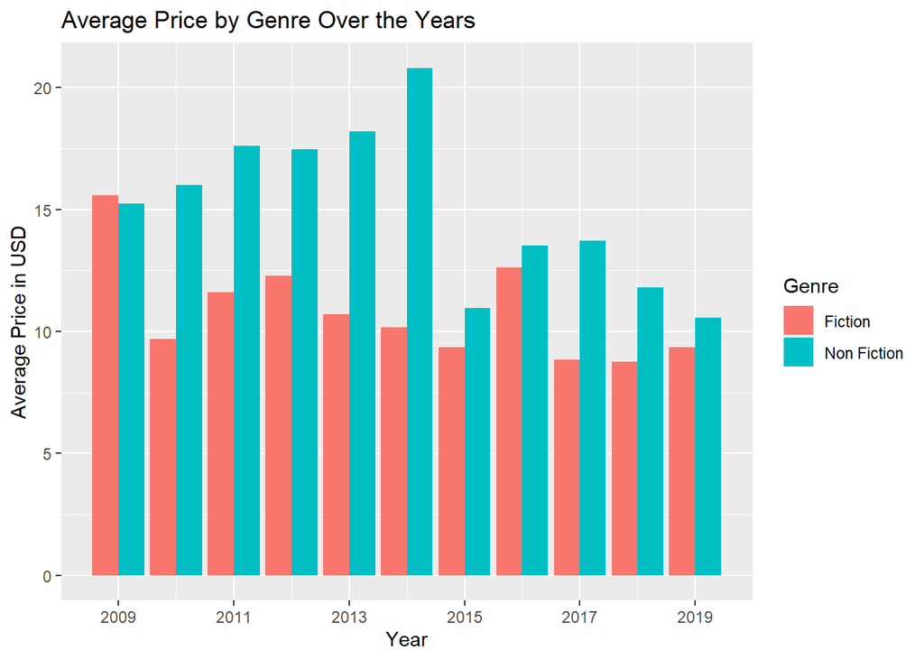

```r
avg_price_by_genre %>%
  ggplot(aes(x=Year, y=mean, fill=Genre)) +
  geom_bar(stat='identity', position='dodge') +
  xlim(2009, 2019) +
  scale_x_continuous(breaks=c(2009, 2011, 2013, 2015, 2017, 2019)) +
  labs(title="Average Price by Genre Over the Years") +
  ylab("Average Price in USD") +
  xlab("Year")
```

### Reviews by Genre

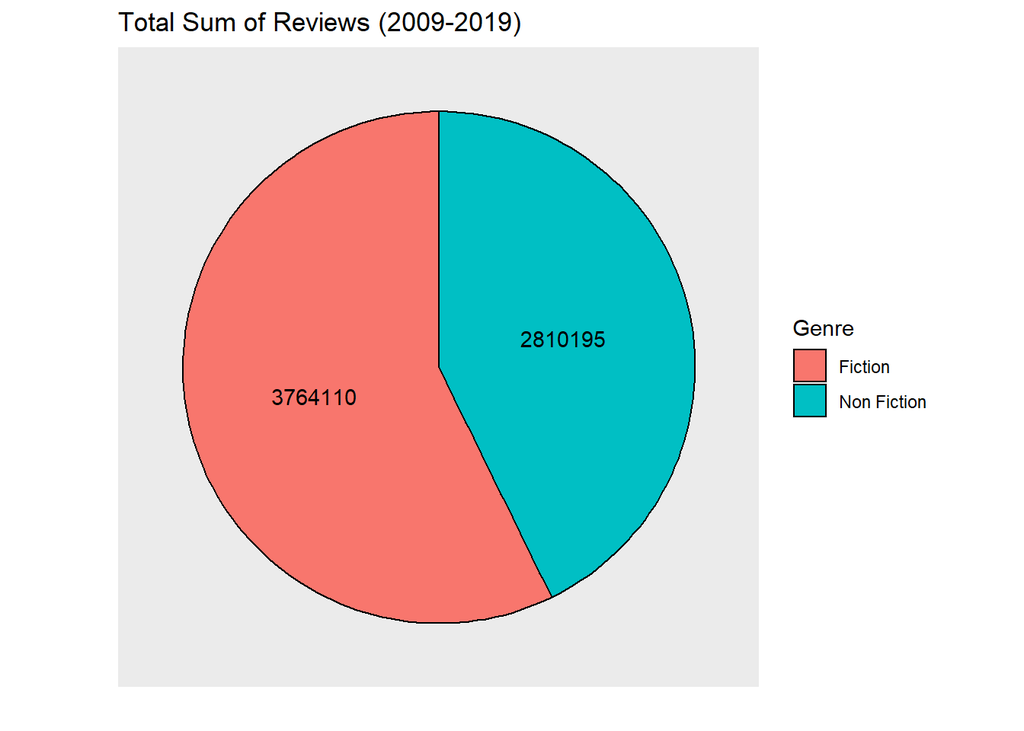

```r
review_count <- bestsellers %>%
  group_by(Genre) %>%
  summarize(sum=sum(Reviews))

review_count %>%
  ggplot(aes(x="", y=sum, fill= Genre)) +
  geom_col(color="black") +
  coord_polar(theta="y") +
  geom_text(aes(label=(sum)), position = position_stack(vjust=0.5)) +
  theme(axis.text = element_blank(),
        axis.ticks = element_blank(),
        panel.grid = element_blank()) +
  labs(title="Total Sum of Reviews (2009-2019)") +
  xlab("") +
  ylab("")
```

From this graph, we can see that Fiction novels had a much higher number of reviews than Non-Fiction books.

### Conclusion

In this notebook, we cleaned up and analyzed the top 50 bestselling books on amazon dataset. From Exploratory Data Analysis, our findings showed:

- The majority of bestsellers had over a 4.0 rating, with only a select few with a lower rating than that.
- There were 28 books with a 4.9 rating, which was the highest a book was rated.
- Dav Pilkey wrote the most number of bestsellers with a 4.9 rating (6 books).
- Jeff Kinney (Author of Diary of a Wimpy Kid) wrote the most bestsellers overall (12 books).
- There were 240 Fiction and 310 Non-Fiction bestsellers through out 2009-2019.
- The highest priced bestseller is *Diagnostic and Statistical Manual of Mental Disorders, 5th Edition* with a price of $105.
- There were no strong correlations between User Rating and other attributes (Reviews, Price, Year, Genre)
- The most a book became a bestseller is *Publication Manual of the American Psychological Association, 6th Edition* with it being a bestseller for 10 years
- There were more Non-Fiction books than Fiction books in the top 50 bestsellers for all years with the exception of 2014.
- Non-fiction books had a higher average price for all years with the exception of 2009.
- Fiction books had more reviews than that of Non Fiction books.

From this analysis, we can see that it may be more favorable for a publisher to publish a nonfiction book over a fiction book. However, it is important to consider that Fiction books had more user interaction with a higher number of reviews.